# Diversidad alfa

# Introduccion

Como mencione anteriormente, la diversidad alfa es la diversidad media de especies en u sitio a escala local. Este es el primer nivel de comparacion de diversidad que van a usar para comparar sus muestras

```r
library("microbiome")
```

# Indices de diversidad alfa

Calcular la diversidad alfa en realidad es bastante sencillo. El reto para ustedes sera interpretar esos datos:

La funcion base de phyloseq calcula 7 metodos diferentes para diversidad alfa:

1. *Observed:* cuenta el numero de especies por muestra (riqueza de especies)
2. *Chao1:* Estimador de riqueza de especie bajo la hipótesis de que las especies raras dan la mayor información sobre aquellas que no se observaron. Chao1 es usado por lo regular para muestras pequeñas y es particularmente útil en datos sesgados a especies de baja abundancia.
3. *ACE:* Abundance-based coverage estimator (ACE) es otro estimador no parametrico de riqueza de especie que usa la covertura de la muestra, basado en la suma de las probabilidades de las especies observadas
4. *Shannon H’:* es un indice que integra tanto riqueza como uniformidad. Sin entrar en las matematicas Shannon le pone mas enfasis en sus calculos a la riqueza de especies como componente y a la cobertura de especies raras.
5. *Simpson D1:* Es una medida de diversidad que tiene en cuenta el número de especies presentes, así como la abundancia relativa de cada especie. A medida que aumentan la riqueza y la uniformidad de las especies, también aumenta la diversidad. El valor de D oscila entre 0 y 1. El índice de Simpson pone mayor énfasis en el componente de uniformidad y en los tipos de cobertura dominantes. mas cercano 1 las muestras son mas unifromes(mas diversidad), ms cercano a 0 menos especies
6. Dado que Simpson mide la probabilidad de que dos individuos seleccionados aleatoriamente de una muestra pertenezcan a la misma especie (o a alguna categoría distinta de especie) tambien se puede calcular *InvSimpson*
7. *Fisher:* Este es un índice paramétrico de diversidad que supone que la abundancia de especies sigue la distribución de la serie logarítmica.

```r
estimate_richness(vid_bio, split = TRUE,
                  measures = c("Observed", "Chao1", "Shannon", "Simpson"))
```

[output not shown]

## Otros indices de diversidad que pueden calcular

```r
# del paquete microbiome
Evenness <- evenness(vid_bio, index = 'all',
                     zeroes = TRUE,
                     detection =0) # default
```

```
Error in evenness(vid_bio, index = "all", zeroes = TRUE, detection = 0) :
  no se pudo encontrar la función "evenness"
```

8. *Pielou:* equidad (tambien conocida como equidad de Pielou) es la diversidad de shannon dividida por el logritmo del numero de taxones presentes

[Mas info en indices de diversidad](https://www.nhm.uio.no/english/research/resources/past/help/diversity.html)

# Graficando diversidad alfa

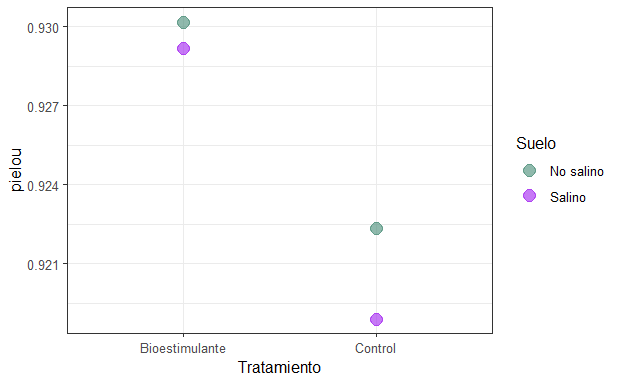

# Análisis estadistico

Como con los datos que vimos durante ese modulo, el analisis estadistico seguira el mismo flujo de trabajo que vimos y lo deberan elegir depenediendo su num de muestras, tratamietnos, etc

```r
# shapiro test
for(i in 3:16){ # cambia dependiendo de los datos
  shapiro <- shapiro.test(alphadiv[,i])
  normal <- ifelse(shapiro[["p.value"]]>0.05, "YES", "NO")
  print(c(i, normal))
}
```

```
[1] "3"   "YES"
[1] "4"   "YES"
[1] "5"   "YES"
[1] "6"   "YES"
[1] "7"   "YES"
[1] "8"   "YES"
[1] "9"   "YES"
[1] "10"  "YES"
[1] "11"  "YES"
[1] "12" "NO"
[1] "13"  "YES"
[1] "14"  "YES"
[1] "15"  "YES"
[1] "16"  "YES"
```